# Problem Set 06 Solutions

# Independent analysis

You will now use the tools you have learned, and a new data set to solve a conservation problem.

Wildlife biologists are interested in managing/protecting habitats for a declining species of vole, but are not sure about what habitats it prefers. Two things that biologists can easily control with management is percent cover of vegetation, and where habitat improvements occur (i.e. is it important to create/protect habitat in moist or dry sites, etc). To help inform habitat management of this vole species, the researchers in this study counted the number of `voles` at 56 random study sites. At each site, they measured percent cover of `veg`etation, and recorded whether a site had moist or dry `soil`.

The data can be read in like so:

```r
vole_trapping <- read_csv("http://bit.ly/2IgDF0E")
```

The data contains the variables:

- `site` for the id of each random study site (each case or row is a survey/trapping site)
- `voles` for the vole count at each site
- `veg` for the percent cover of vegetation at each site
- `soil` identifying a site as “moist” or “dry”

Generate an appropriate regression model with `voles` as the response variable `y`, and `veg` and `soil` as explanatory variables. Use the results of the model to answer the following questions **based on the available data**. A data visualization will probably also help you.

## Note to grader

**Students do not need to make this *exact* plot, the point is just that they realize to use regression to answer an applied question, and do not just use their opinion on the matter to answer. The parallel slopes model should be preferred here, but don’t penalize their predictions if they don’t choose it.**

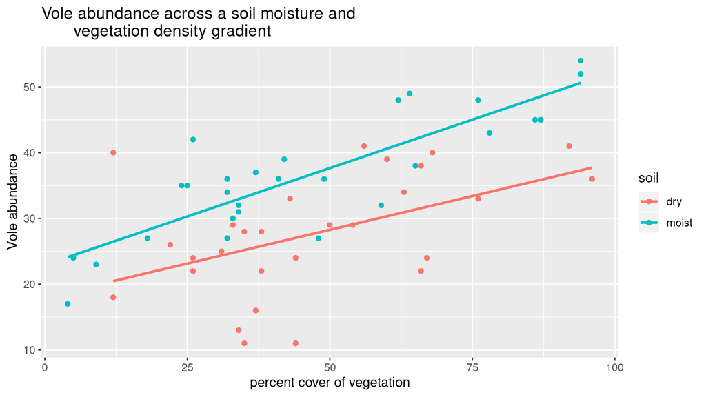

```r
ggplot(data = vole_trapping, aes(x = veg, y = voles, color = soil)) +
  geom_point() +
  geom_smooth(method = "lm", se = F) +
  labs(title = "Vole abundance across a soil moisture and
       vegetation density gradient", x = "percent cover of vegetation",
       y = "Vole abundance")
```

```r
vole_parallel_model <- lm(voles ~ soil + veg, data = vole_trapping)
get_regression_table(vole_parallel_model)
```

| term | estimate | std_error | statistic | p_value | lower_ci | upper_ci |
| --- | --- | --- | --- | --- | --- | --- |
| intercept | 15.464 | 2.197 | 7.039 | 0 | 11.058 | 19.870 |
| soilmoist | 9.100 | 1.800 | 5.057 | 0 | 5.491 | 12.710 |
| veg | 0.259 | 0.038 | 6.840 | 0 | 0.183 | 0.335 |

```r
vole_interaction_model <- lm(voles ~ soil * veg, data = vole_trapping)
get_regression_table(vole_interaction_model)
```

| term | estimate | std_error | statistic | p_value | lower_ci | upper_ci |
| --- | --- | --- | --- | --- | --- | --- |
| intercept | 18.003 | 3.103 | 5.802 | 0.000 | 11.777 | 24.229 |
| soilmoist | 4.930 | 4.032 | 1.223 | 0.227 | -3.161 | 13.020 |
| veg | 0.205 | 0.060 | 3.430 | 0.001 | 0.085 | 0.326 |
| soilmoist:veg | 0.089 | 0.077 | 1.155 | 0.253 | -0.066 | 0.244 |

# Question 10

Would protecting a site with high vegetation cover be a more effective way to preserve the vole population than a site with low vegetation cover? Why?

**Answer:** High vegetation cover; greater vegetation cover is associated with more moles

# Question 11

Dry sites typically cost a lot less to purchase and maintain for conservation organizations. Thus, if a conservation organization decides to purchase a few dry sites, roughly what percent cover of vegetation do they need to maintain on these sites (at a minimum) to support a population of about 30 voles at the site?

**Answer:** Eyeballing it from the graph, ~ 55% **[Note to grader…they can solve this other ways too…so long as they get something in this range through looking at the data, they should receive credit. ]**

# Question 12

The Nature Conservancy is looking at purchasing a site for this species (in the same study area) that has moist soil and 40% vegetation cover. **Using the regression equation** what would you predict as the possible vole population the site might be able to support?

**Answer:**

- **Parallel Slopes: 15.46 + (0.259 * 40) + (9.1 *1) = 34.92, so 34 or 35 voles**
- **Interaction Model: 18 + (4.93*1) + (.205 + (.089*1)) * 40 = 34.69, so again 34 or 25 voles**